# SAMN17249466_QC

Jacopo Umberto Verga

2022-11-17

# Quality control and filtering results from cellranger

## Sample info and environment setup

# PRJNA694128

- Bioproject: PRJNA694128
- [Article](https://www.nature.com/articles/s41467-021-22804-x): Co-evolution of tumor and immune cells during progression of multiple myeloma
- Journal: Nature communications
- Samples: 29 from 14 patients, SMM, primary, relapsed MM, BM and sorted CD138+ cells
- Data format: .bam files obtained with CellRanger
- Technology: 10x Chromium
  - Bam file: [SAMN17249466](https://sra-pub-src-2.s3.amazonaws.com/SRR13509392/scRNA.unsorted.59114_Pre_transplant.bam.1) (BM - pre-transplant)
  - bamtofast (built-in CellRanger) to obtain 2 set (lines) of fastq files (R1, R2 I1)
  - cellranger + `EmptyDroplets` (FDR <= 0.1)

```r
 setwd("/media/jacopo/Elements/re_align/MM/PRJNA694128/59114/SAMN17249466/")
# Load the libraries (from Sarah script + biomart)
library(tidyverse) # packages for data wrangling, visualization etc
library(Seurat) # scRNA-Seq analysis package
library(clustree) # plot of clustering tree
library(ggsignif) # Enrich your 'ggplots' with group-wise comparisons
library(clusterProfiler) #The package implements methods to analyze and visualize functional profiles of gene and gene clusters.
library(org.Hs.eg.db) # Human annotation package neede for clusterProfiler
library(ggrepel) # extra geoms for ggplo2
library(patchwork) #multiplots
library(reticulate)
```

## Load and process cellranger data

Load and do the QC for the cellranger data

```r
#list.files(".")
```

```r
dat <- Read10X(data.dir ="./out/counts_filtered/")
dat <- CreateSeuratObject(dat) # Create the seurat object from the 10x data
kb.initial <- dat@assays[["RNA"]]@counts@Dim[[2]]
cat("Initial number of cells:", kb.initial,
    "\nNumber of genes:",  dat@assays[["RNA"]]@counts@Dim[[1]])
```

```
## Initial number of cells: 2349
## Number of genes: 36601
```

## Quality Control

Empty cells were already filtered, check for % mt RNA and death markers:

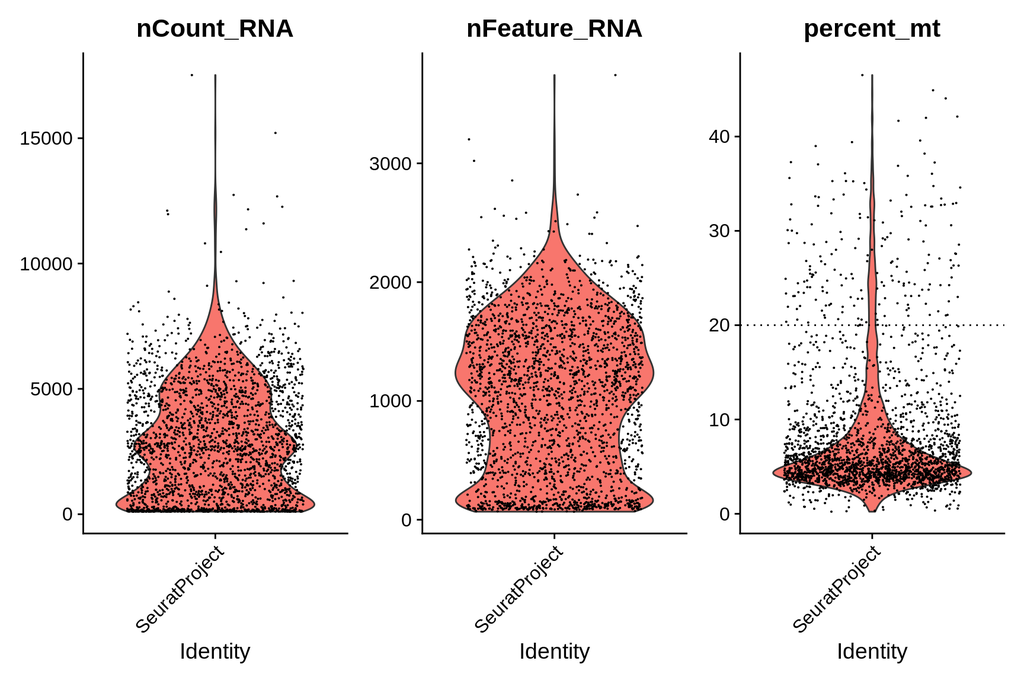

```r
# first calculate the mitochondrial percentage for each cell
dat$percent_mt <- PercentageFeatureSet(dat, pattern="^MT.")
# make violin plots
mt_rna = 20
max_counts = 15000



# Check some feature-feature relationships
# % mt RNA vs n Counts, n Features vs n Counts
# Check some feature-feature relationships
# % mt RNA vs n Counts, n Features vs n Counts
VlnPlot(dat, features = c("nCount_RNA", "nFeature_RNA", "percent_mt"))  + geom_hline(yintercept=mt_rna, linetype = "dotted")
```

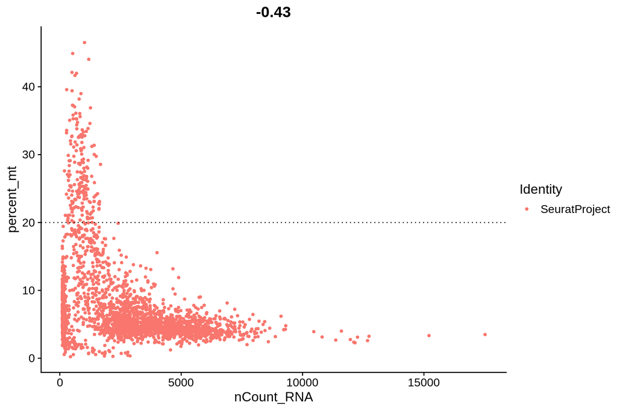

```r
plot1 <- FeatureScatter(dat, feature1 = "nCount_RNA", feature2 = "percent_mt")
plot1 <- plot1 + geom_hline(yintercept=mt_rna, linetype = "dotted")
plot2 <- FeatureScatter(dat, feature1 = "nCount_RNA", feature2 = "nFeature_RNA")
plot2 <- plot2 + geom_vline(xintercept = max_counts, linetype = "dotted")
plot1
```

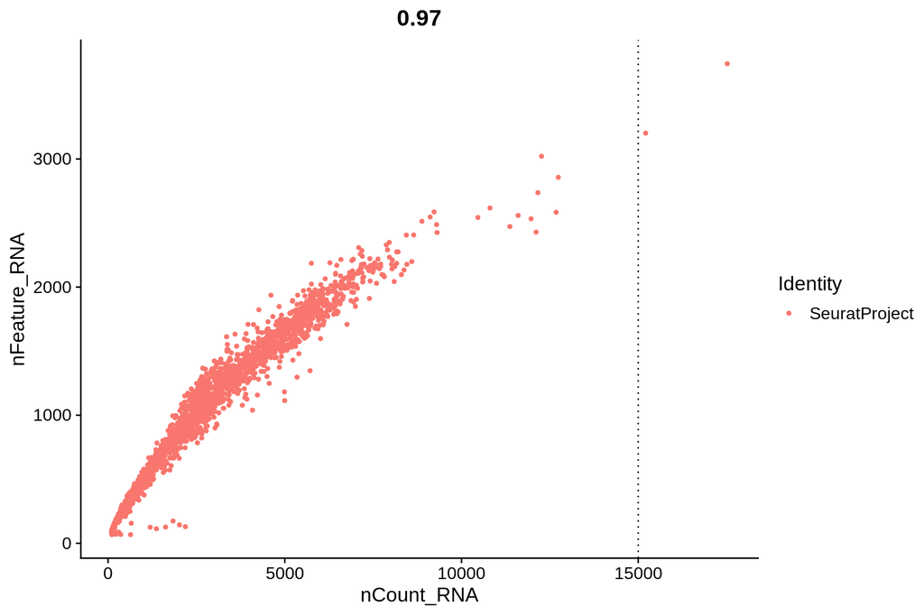

```
##  cells retained by mt RNA content ( 20 %): 2159
##  percentage of retained cells: 91.91 %
```

```
## cells retained by counts ( 15000 ): 2157
##  percentage of retained cells: 91.83 %
```

```r
plot2
```

Check the distribution of the cells with low counts and control death markers:

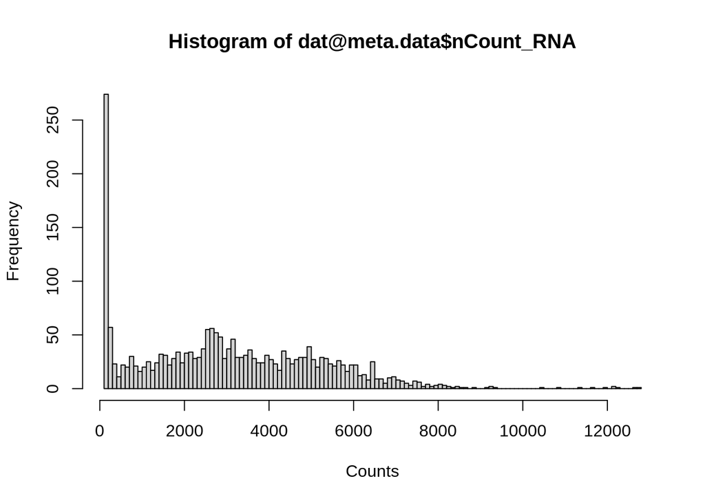

```r
min_counts = 250


hist(dat@meta.data$nCount_RNA, breaks = 100, xlab = "Counts")
```

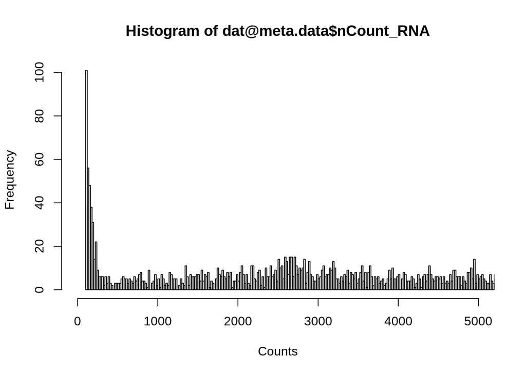

```r
hist(dat@meta.data$nCount_RNA, breaks = 500, xlab = "Counts", xlim = c(0,5000))
```

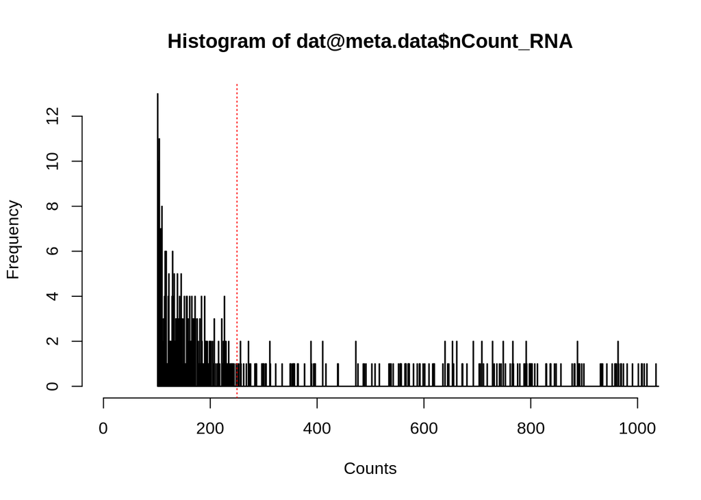

```r
hist(dat@meta.data$nCount_RNA, breaks = 10000, xlab = "Counts", xlim = c(0,1000))
abline(v=min_counts, col="red", lty = 3)
```

```
##    MALAT1    MT-CO1    TMSB4X    S100A9       B2M    MT-CO2    MT-CO3       FTL
## 2.8853503 2.1974522 2.1910828 2.1337580 2.0509554 1.9490446 1.6910828 1.5159236
##    S100A8       LYZ      ACTB      FTH1    TMSB10    MT-ND2    MT-ND4     RPL10
## 1.4012739 1.3980892 1.2101911 1.2070064 1.0127389 0.9554140 0.9458599 0.8757962
##       HBB    EEF1A1   MT-ATP6     RPL41    RPL13A    MT-CYB     RPS18     RPS27
## 0.8471338 0.8025478 0.7070064 0.6974522 0.6687898 0.6560510 0.6433121 0.6401274
##     RPL13    S100A4     RPS12    MT-ND1     RPL11      HBA2
## 0.6114650 0.6082803 0.5764331 0.5764331 0.5668790 0.5668790
```

```
## cells retained by counts ( 250 ): 1843
##  percentage of retained cells: 78.46 %
```

[figure not shown]

```r
# Subset the dataset to focus only on those cells with low counts
dat.lowcount <- subset(dat, subset = nCount_RNA < min_counts)

# Get the mean of the counts for each gene and sort them decreasing
meanCounts <- rowMeans(GetAssayData(object = dat.lowcount, slot = 'counts'))
meanCounts <- sort(meanCounts, decreasing = T)

# A boxplot can help to observe the distribution of the means
#boxplot(meanCounts)

# Print the most highly expressed genes
head(meanCounts, 30)
```

```r
dir.create("result")
saveRDS(dat, file = "./result/SAMN17249466_clean_QC.Rds")
```

## Feature selection

```r
#Normalize
dat <- NormalizeData(dat)
# Find the first 4000 variabe features
dat <- FindVariableFeatures(dat, selection.method = "vst", nfeatures = 4000)
```

## Data scaling

Set mean expression to 0 and variance across 1 to avoid highly expressed genes drive the forwarding analyses. Since negative expression is meaningless, scaled data are useful only for UMAP and clustering

```r
# scale data, the scaled data are saved in:
# dat[["RNA"]]@scale.data

all.genes <- rownames(dat)

dat <- ScaleData(dat, vars.to.regress = c("percent_mt","nCount_RNA"))
```

## Dimensionality reduction

```r
dat <- RunPCA(dat, features = VariableFeatures(object = dat), verbose = F, seed.use = 1)
print(dat[["pca"]], dims = 1:5, nfeatures = 5)
```

```
## PC_ 1
## Positive:  IFITM1, CTSW, GZMA, CST7, NKG7
## Negative:  LYZ, FTL, S100A9, FCN1, S100A6
## PC_ 2
## Positive:  IL7R, LTB, CD3D, TRAC, CD3G
## Negative:  GZMB, GNLY, KLRF1, PRF1, FCER1G
## PC_ 3
## Positive:  IFITM3, FCGR3A, CDKN1C, HLA-DPA1, HES4
## Negative:  S100A12, VCAN, S100A8, S100A9, AC020656.1
## PC_ 4
## Positive:  HLA-DQA1, FCER1A, HLA-DPB1, CLEC10A, HLA-DQA2
## Negative:  CD3D, IL7R, FOLR3, TRAC, LTB
## PC_ 5
## Positive:  HBB, HBA1, HBA2, HBD, AHSP
## Negative:  RPS18, EEF1A1, RPS2, RPS29, RPS8
```

## UMAP

UMAP is a graph-based method of clustering. The first step in this process is to construct a KNN graph based on the euclidean distance in PCA space:

```r
dat <- FindNeighbors(dat, dims = 1:20)
```

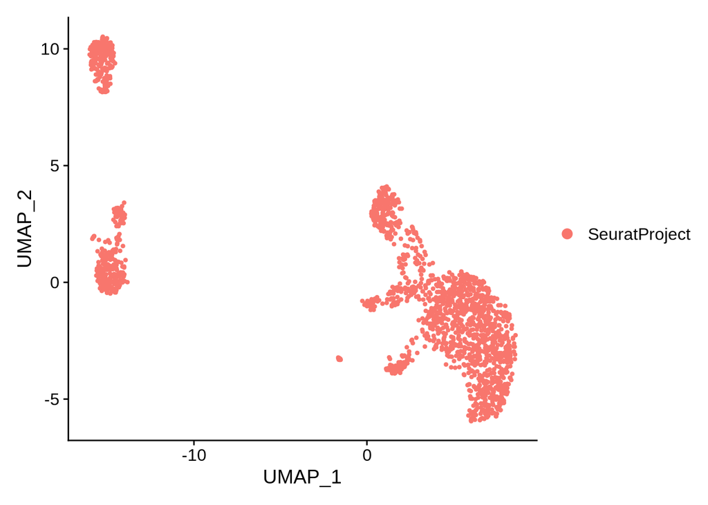

```r
dat <- RunUMAP(dat, dims = 1:20, seed.use = 1)
DimPlot(dat, reduction = 'umap', seed = 1)
```

## Final plots:

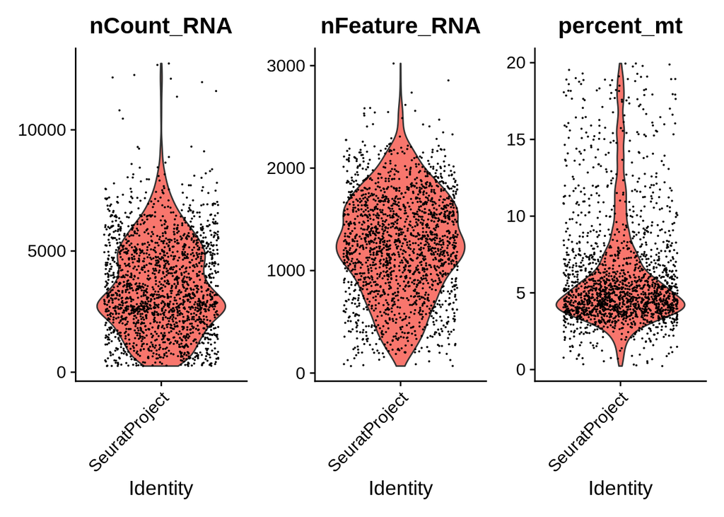

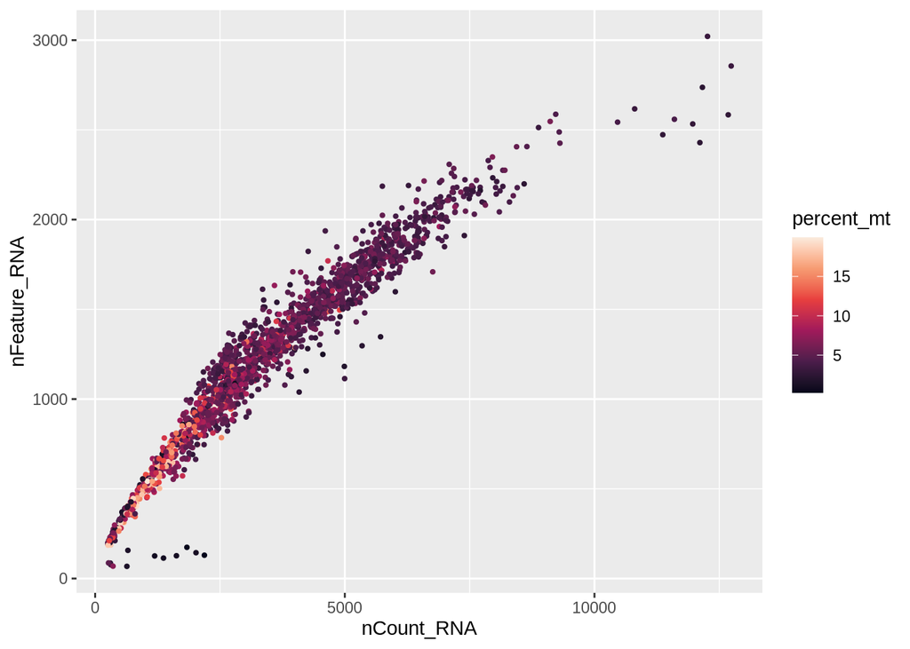

```
## QC metrics
```

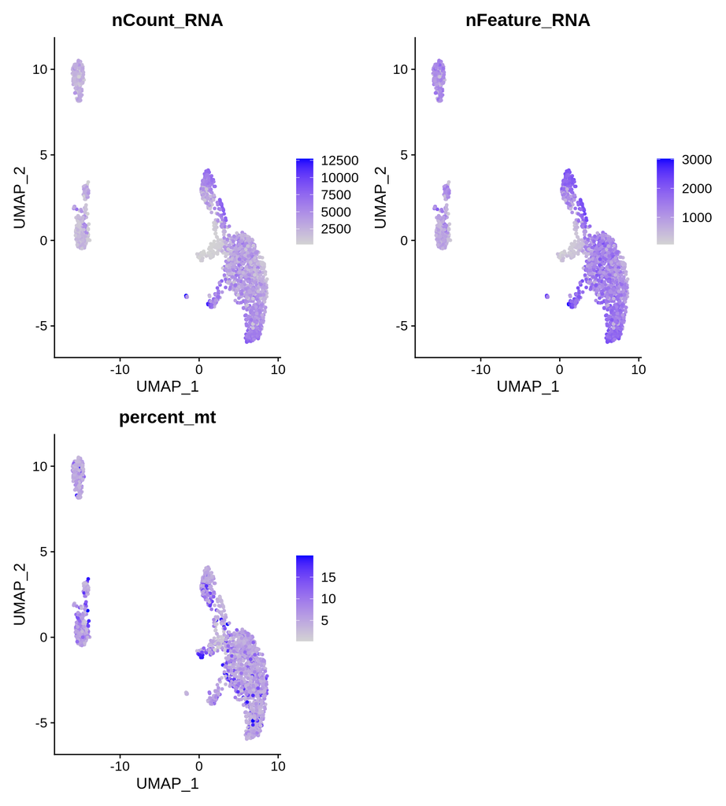

```
## markers
```

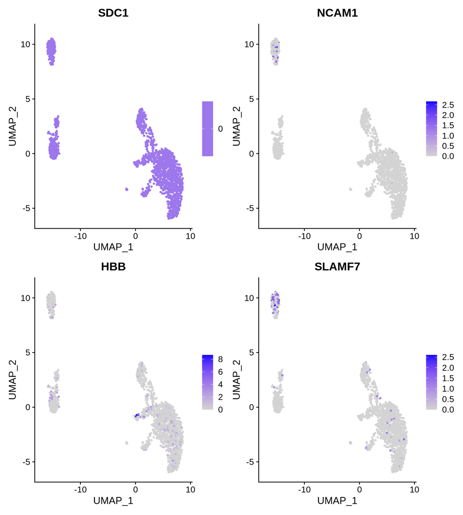